# Module 6 Assignment 1 - Digit Recognizer

**Research project problem statement:**  
Recognize handwritten digits.  
**Requirement:**  
1. Fit a random forest classifier using the full set of explanatory variables and the model training set (csv).  
2. Record the time it takes to fit the model and then evaluate the model on the csvdata by submitting to Kaggle.com. Provide your Kaggle.com score and user ID.  
3. Execute principal components analysis (PCA) on the combined training and test set data together, generating principal components that represent 95 percent of the variability in the explanatory variables. The number of principal components in the solution should be substantially fewer than the explanatory variables.  
4. Record the time it takes to identify the principal components.  
5. Using the identified principal components from step (2), use thecsvto build another random forest classifier.  
6. Record the time it takes to fit the model and to evaluate the model on the csvdata by submitting to Kaggle.com. Provide your Kaggle.com score and user ID.  
7. Use k-means clustering to group MNIST observations into 1 of 10 categories and then assign labels. (Follow the example here if needed: kmeans mnist.pdf Download kmeans mnist.pdf).kmeans mnist-2.pdf Download kmeans mnist-2.pdf  
8. Submit the RF Classifier, the PCA RF, and k-means estimations to Kaggle.com, and provide screen snapshots of your scores as well as your Kaggle.com user name.  
9. The experiment we have proposed has a major design flaw. Identify the flaw. Fix it. Rerun the experiment in a way that is consistent with a training-and-test regimen, and submit this to Kaggle.com.

```python
# set up notebook to display multiple output in one cell
from IPython.core.interactiveshell import InteractiveShell
InteractiveShell.ast_node_interactivity = "all"
```

```python
# load libraries
import pandas as pd
import numpy as np
import datetime
```

```python
# import base packages into the namespace for this program
import numpy as np
import pandas as pd
import matplotlib.pyplot as plt
import seaborn as sns
from pandas.plotting import scatter_matrix

# modeling routines from Scikit Learn packages
# from sklearn.metrics import confusion_matrix, ConfusionMatrixDisplay
import matplotlib.pyplot as plt
from sklearn.metrics import confusion_matrix, ConfusionMatrixDisplay
###imports for modeling
# For preprocessing the data
from sklearn import preprocessing
# To split the dataset into train and test datasets
from sklearn.model_selection import train_test_split
# To model the Gaussian Navie Bayes classifier
from sklearn.naive_bayes import GaussianNB
# To calculate the accuracy score of the model
from sklearn import metrics

from sklearn.linear_model import LogisticRegression
from sklearn.cluster import MiniBatchKMeans
from sklearn.model_selection import GridSearchCV, LeaveOneOut
from sklearn.metrics import roc_curve, auc
```

```python
%matplotlib inline
root = "C:/Users/91984/Desktop/Abhishek/NU MS/422 -ML/Digit Recognizer/files/"
```

## EDA

```python
train=pd.read_csv(root + '/train.csv')
test=pd.read_csv(root + '/test.csv')
```

```python
#Printing the size of the dataframe
print ("Training dataset has %i observations and %i variables" %(train.shape[0], train.shape[1]))
print ("Testing dataset has %i observations and %i variables" %(test.shape[0], test.shape[1]))
```

```
Training dataset has 42000 observations and 785 variables
Testing dataset has 28000 observations and 784 variables
```

```python
#check 2 rows
train.head(2)
```

|  | label | pixel0 | pixel1 | pixel2 | pixel3 | pixel4 | pixel5 | pixel6 | pixel7 | pixel8 | ... | pixel774 | pixel775 | pixel776 | pixel777 | pixel778 | pixel779 | pixel780 | pixel781 | pixel782 | pixel783 |
| --- | --- | --- | --- | --- | --- | --- | --- | --- | --- | --- | --- | --- | --- | --- | --- | --- | --- | --- | --- | --- | --- |
| 0 | 1 | 0 | 0 | 0 | 0 | 0 | 0 | 0 | 0 | 0 | ... | 0 | 0 | 0 | 0 | 0 | 0 | 0 | 0 | 0 | 0 |
| 1 | 0 | 0 | 0 | 0 | 0 | 0 | 0 | 0 | 0 | 0 | ... | 0 | 0 | 0 | 0 | 0 | 0 | 0 | 0 | 0 | 0 |

2 rows × 785 columns

```python
train.info()
```

```
<class 'pandas.core.frame.DataFrame'>
RangeIndex: 42000 entries, 0 to 41999
Columns: 785 entries, label to pixel783
dtypes: int64(785)
memory usage: 251.5 MB
```

```python
#Seperate the target and independant variables
X=train.iloc[:,1:]
y=train.iloc[:,0]
```

```python
def show_image(row, X,y):
    temp=X.iloc[row,:].values
    temp = temp.reshape(28,28).astype('uint8')
    plt.imshow(temp)
    plt.title("Label:" +  str(y.iloc[row]))
```

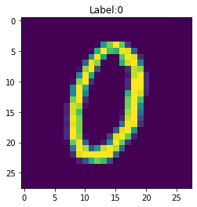

```python
show_image(5, X, y)
```

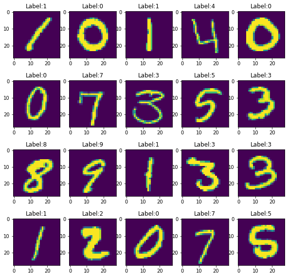

```python
##Display multiple images
plt.figure(figsize=(10,10))
for i in range(20):
    plt.subplot(4, 5, i+1)
    show_image(i, X, y)
```

#### Class Distribution

```python
#Check the frequency of each number
y.value_counts().sort_index()
```

```
0    4132
1    4684
2    4177
3    4351
4    4072
5    3795
6    4137
7    4401
8    4063
9    4188
Name: label, dtype: int64
```

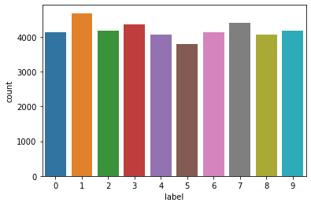

```python
sns.countplot(y)
```

```python
#Split the dataset
X_train, X_test, y_train, y_test = train_test_split(X, y, test_size=0.2, random_state=0)
print(X_train.shape)
print(X_test.shape)
```

```
(33600, 784)
(8400, 784)
```

### Requirement 1:

#### Fit a random forest classifier using the full set of explanatory variables and the model training set (csv).

#### Record the time it takes to fit the model and then evaluate the model on the csvdata by submitting to Kaggle.com. Provide your Kaggle.com score and user ID.

```python
from sklearn.ensemble import RandomForestClassifier
from sklearn.model_selection import GridSearchCV

forrest_params = dict(
    n_estimators = [50, 150, 200]
)
forrest = RandomForestClassifier()
```

```python
start=datetime.datetime.now()

forest_cv = GridSearchCV(estimator=forrest, param_grid=forrest_params, cv=5)
forest_cv.fit(X_train, y_train)

end=datetime.datetime.now()
print(f'execution time: {end-start}')
```

```
GridSearchCV(cv=5, estimator=RandomForestClassifier(),
             param_grid={'n_estimators': [50, 150, 200]})
```

```
execution time: 0:06:00.913254
```

```python
print("Best Train Score: {}".format(forest_cv.best_score_))
print("Best Estimator: {}".format(forest_cv.best_estimator_))
```

```
Best Train Score: 0.9635714285714286
Best Estimator: RandomForestClassifier(n_estimators=200)
```

```python
forest_cv.best_estimator_.score(X_test,y_test)
```

```
0.9655952380952381
```

### Kaggle Submission (Random Forest)

```python
forest_pred = forest_cv.predict(test)
forest_pred_csv = pd.DataFrame({"ImageId": range(1,len(forest_pred)+1),"Label": forest_pred})

forest_pred_csv.to_csv(root + 'forest_submission.csv', index=False, header=True)
```

#### Kaggle Score: 0.96585

#### Position on Leader Board: 1157

### Requirement 2:

#### Execute principal components analysis (PCA) on the combined training and test set data together, generating principal components that represent 95 percent of the variability in the explanatory variables. The number of principal components in the solution should be substantially fewer than the explanatory variables.

#### Principal Component Analysis

#### PCA - Training +Testing

```python
all_data = train+test
```

```python
train.shape
```

```
(42000, 785)
```

```python
test.shape
```

```
(28000, 784)
```

```python
all_data = pd.concat([train, test])
```

```python
all_data.shape
```

```
(70000, 785)
```

```python
all_data.head(2)
```

|  | label | pixel0 | pixel1 | pixel2 | pixel3 | pixel4 | pixel5 | pixel6 | pixel7 | pixel8 | ... | pixel774 | pixel775 | pixel776 | pixel777 | pixel778 | pixel779 | pixel780 | pixel781 | pixel782 | pixel783 |
| --- | --- | --- | --- | --- | --- | --- | --- | --- | --- | --- | --- | --- | --- | --- | --- | --- | --- | --- | --- | --- | --- |
| 0 | 1.0 | 0 | 0 | 0 | 0 | 0 | 0 | 0 | 0 | 0 | ... | 0 | 0 | 0 | 0 | 0 | 0 | 0 | 0 | 0 | 0 |
| 1 | 0.0 | 0 | 0 | 0 | 0 | 0 | 0 | 0 | 0 | 0 | ... | 0 | 0 | 0 | 0 | 0 | 0 | 0 | 0 | 0 | 0 |

2 rows × 785 columns

```python
all_data=all_data.iloc[:,1:]
```

```python
all_data.head(2)
```

|  | pixel0 | pixel1 | pixel2 | pixel3 | pixel4 | pixel5 | pixel6 | pixel7 | pixel8 | pixel9 | ... | pixel774 | pixel775 | pixel776 | pixel777 | pixel778 | pixel779 | pixel780 | pixel781 | pixel782 | pixel783 |
| --- | --- | --- | --- | --- | --- | --- | --- | --- | --- | --- | --- | --- | --- | --- | --- | --- | --- | --- | --- | --- | --- |
| 0 | 0 | 0 | 0 | 0 | 0 | 0 | 0 | 0 | 0 | 0 | ... | 0 | 0 | 0 | 0 | 0 | 0 | 0 | 0 | 0 | 0 |
| 1 | 0 | 0 | 0 | 0 | 0 | 0 | 0 | 0 | 0 | 0 | ... | 0 | 0 | 0 | 0 | 0 | 0 | 0 | 0 | 0 | 0 |

2 rows × 784 columns

```python
training_size = train.shape[0]
training_size
```

```
42000
```

```python
from sklearn.preprocessing import StandardScaler
standardized_all_data = StandardScaler().fit_transform(all_data)
standardized_all_data.shape
```

```
(70000, 784)
```

```python
from sklearn import decomposition
pca = decomposition.PCA()
pca.n_components = 2
pca_data_2 = pca.fit_transform(standardized_all_data)
pca_data_2.shape
```

```
(70000, 2)
```

```python
pca_data_2[:training_size].shape
```

```
(42000, 2)
```

```python
pca_data_2_new = pd.DataFrame({"1st_principal" : pca_data_2[:training_size].T[0], "2nd_principal" : pca_data_2[:training_size].T[1], "label" : y})
```

```python
pca_data_2_new
```

|  | 1st_principal | 2nd_principal | label |
| --- | --- | --- | --- |
| 0 | -5.230248 | -4.905645 | 1 |
| 1 | 19.375866 | 5.922595 | 0 |
| 2 | -7.675852 | -1.518005 | 1 |
| 3 | -0.360881 | 5.989432 | 4 |
| 4 | 26.628413 | 5.803899 | 0 |
| ... | ... | ... | ... |
| 41995 | 13.709907 | -1.697052 | 0 |
| 41996 | -8.890670 | -0.962354 | 1 |
| 41997 | 0.657699 | 6.424172 | 7 |
| 41998 | 2.337828 | -4.345047 | 6 |
| 41999 | -4.737035 | 1.508433 | 9 |

42000 rows × 3 columns

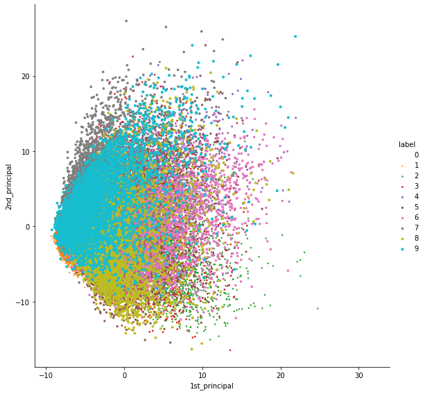

```python
sns.FacetGrid(pca_data_2_new, hue='label',height=8).map(plt.scatter, "1st_principal", "2nd_principal", 'label').add_legend()
plt.show()
```

### Requirement 3:

#### Record the time it takes to identify the principal components.

```python
start=datetime.datetime.now()

pca.n_components = 784

pca_data = pca.fit_transform(standardized_all_data)

percentage_var_explained = pca.explained_variance_ / np.sum(pca.explained_variance_)

#cumulative sum of the percentage_var_explained
cumulative_explained_variance = np.cumsum(percentage_var_explained)

end=datetime.datetime.now()
print(f'Time to identify principal components: {end-start}')
```

```
Time to identify principal components: 0:00:10.459907
```

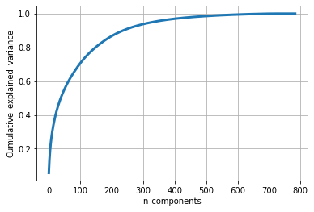

```python
plt.figure(figsize=(6,4))
plt.plot(cumulative_explained_variance,linewidth=3)
plt.grid()

plt.xlabel('n_components')
plt.ylabel('Cumulative_explained_variance')
plt.show()
```

#### the above graph shows that by choosing 250 principal components, we can get a variance of around 90%

```python
pca.n_components = 250

pca_data = pca.fit_transform(standardized_all_data)
```

```python
pca_data[:training_size].shape
```

```
(42000, 250)
```

```python
y.shape
```

```
(42000,)
```

### Requirement 4:

#### Using the identified principal components from step (2), use thecsvto build another random forest classifier.

#### Record the time it takes to fit the model and to evaluate the model on the csvdata by submitting to Kaggle.com. Provide your Kaggle.com score and user ID.

```python
start=datetime.datetime.now()

forest_cv_pca = GridSearchCV(estimator=forrest, param_grid=forrest_params, cv=5)
forest_cv_pca.fit(pca_data[:training_size], y)

end=datetime.datetime.now()
print(f'execution time: {end-start}')
```

```
GridSearchCV(cv=5, estimator=RandomForestClassifier(),
             param_grid={'n_estimators': [50, 150, 200]})
```

```
execution time: 0:31:03.043910
```

### Kaggle Submission - Random Forest with PCA

```python
pca_data[training_size:].shape
```

```
(28000, 250)
```

```python
forest_pca_pred = forest_cv_pca.predict(pca_data[training_size:])
forest_pca_pred_csv = pd.DataFrame({"ImageId": range(1,len(forest_pca_pred)+1),"Label": forest_pca_pred})

forest_pca_pred_csv.to_csv(root + 'forest_pca_submission.csv', index=False, header=True)
```

### Kaggle Score: 0.93910

### Requirement 5:

#### Use k-means clustering to group MNIST observations into 1 of 10 categories and then assign labels.

### K-Means

```python
def infer_cluster_labels(kmeans, actual_labels):
    """
    Associates most probable label with each cluster in KMeans model
    returns: dictionary of clusters assigned to each label
    """

    inferred_labels = {}

    for i in range(kmeans.n_clusters):

        # find index of points in cluster
        labels = []
        index = np.where(kmeans.labels_ == i)

        # append actual labels for each point in cluster
        labels.append(actual_labels[index])

        # determine most common label
        if len(labels[0]) == 1:
            counts = np.bincount(labels[0])
        else:
            counts = np.bincount(np.squeeze(labels))

        # assign the cluster to a value in the inferred_labels dictionary
        if np.argmax(counts) in inferred_labels:
            # append the new number to the existing array at this slot
            inferred_labels[np.argmax(counts)].append(i)
        else:
            # create a new array in this slot
            inferred_labels[np.argmax(counts)] = [i]

    return inferred_labels

def infer_data_labels(X_labels, cluster_labels):
    """
    Determines label for each array, depending on the cluster it has been assigned to.
    returns: predicted labels for each array
    """

    # empty array of len(X)
    predicted_labels = np.zeros(len(X_labels)).astype(np.uint8)

    for i, cluster in enumerate(X_labels):
        for key, value in cluster_labels.items():
            if cluster in value:
                predicted_labels[i] = key

    return predicted_labels
```

```python
###########################################
```

```python
# convert each image to 1 dimensional array
X_arry = np.array(X)
X_arry = X_arry.reshape(len(X_arry),-1)

# normalize the data to 0 - 1

X_arry = X_arry.astype(float) / 255.

print(X_arry.shape)
print(X_arry[0].shape)
```

```
(42000, 784)
(784,)
```

#### KMeans, K=10

```python
n_digits = len(np.unique(y))
print(n_digits)

# Initialize KMeans model

kmeans_10 = MiniBatchKMeans(n_clusters = n_digits)

# Fit the model to the training data

kmeans_10.fit(X_arry)

kmeans_10.labels_
```

```
10
```

```
MiniBatchKMeans(n_clusters=10)
```

```
array([3, 6, 5, ..., 1, 2, 8])
```

```python
# test the infer_cluster_labels() and infer_data_labels() functions
cluster_labels = infer_cluster_labels(kmeans_10, np.array(y))
X_clusters = kmeans_10.predict(X_arry)
predicted_labels = infer_data_labels(X_clusters, cluster_labels)
print(predicted_labels[:10])
print(np.array(y[:10]))
```

```
[1 0 1 4 0 6 1 3 3 2]
[1 0 1 4 0 0 7 3 5 3]
```

```python
print(f'accuracy: {np.count_nonzero(predicted_labels == np.array(y))/len(y)}')
```

```
accuracy: 0.5124761904761905
```

#### KMeans, Find k using k-finder

```python
from sklearn.cluster import KMeans
wcss = []
for i in range(1, 50):
#     kmeans = KMeans(n_clusters = i, init = 'k-means++', random_state = 42)
    kmeans_temp = MiniBatchKMeans(n_clusters = i)
    kmeans_temp.fit(X_arry)
    wcss.append(kmeans_temp.inertia_)
```

```
MiniBatchKMeans(n_clusters=1)
```

```
MiniBatchKMeans(n_clusters=2)
```

```
MiniBatchKMeans(n_clusters=3)
```

```
MiniBatchKMeans(n_clusters=4)
```

```
MiniBatchKMeans(n_clusters=5)
```

```
MiniBatchKMeans(n_clusters=6)
```

```
MiniBatchKMeans(n_clusters=7)
```

```
MiniBatchKMeans()
```

```
MiniBatchKMeans(n_clusters=9)
```

```
MiniBatchKMeans(n_clusters=10)
```

```
MiniBatchKMeans(n_clusters=11)
```

```
MiniBatchKMeans(n_clusters=12)
```

```
MiniBatchKMeans(n_clusters=13)
```

```
MiniBatchKMeans(n_clusters=14)
```

```
MiniBatchKMeans(n_clusters=15)
```

```
MiniBatchKMeans(n_clusters=16)
```

```
MiniBatchKMeans(n_clusters=17)
```

```
MiniBatchKMeans(n_clusters=18)
```

```
MiniBatchKMeans(n_clusters=19)
```

```
MiniBatchKMeans(n_clusters=20)
```

```
MiniBatchKMeans(n_clusters=21)
```

```
MiniBatchKMeans(n_clusters=22)
```

```
MiniBatchKMeans(n_clusters=23)
```

```
MiniBatchKMeans(n_clusters=24)
```

```
MiniBatchKMeans(n_clusters=25)
```

```
MiniBatchKMeans(n_clusters=26)
```

```
MiniBatchKMeans(n_clusters=27)
```

```
MiniBatchKMeans(n_clusters=28)
```

```
MiniBatchKMeans(n_clusters=29)
```

```
MiniBatchKMeans(n_clusters=30)
```

```
MiniBatchKMeans(n_clusters=31)
```

```
MiniBatchKMeans(n_clusters=32)
```

```
MiniBatchKMeans(n_clusters=33)
```

```
MiniBatchKMeans(n_clusters=34)
```

```
MiniBatchKMeans(n_clusters=35)
```

```
MiniBatchKMeans(n_clusters=36)
```

```
MiniBatchKMeans(n_clusters=37)
```

```
MiniBatchKMeans(n_clusters=38)
```

```
MiniBatchKMeans(n_clusters=39)
```

```
MiniBatchKMeans(n_clusters=40)
```

```
MiniBatchKMeans(n_clusters=41)
```

```
MiniBatchKMeans(n_clusters=42)
```

```
MiniBatchKMeans(n_clusters=43)
```

```
MiniBatchKMeans(n_clusters=44)
```

```
MiniBatchKMeans(n_clusters=45)
```

```
MiniBatchKMeans(n_clusters=46)
```

```
MiniBatchKMeans(n_clusters=47)
```

```
MiniBatchKMeans(n_clusters=48)
```

```
MiniBatchKMeans(n_clusters=49)
```

#### Elbow plot for finding k

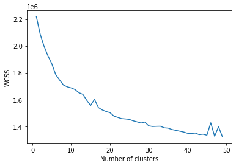

```python
plt.plot(range(1, 50), wcss)
plt.xlabel('Number of clusters')
plt.ylabel('WCSS')
plt.show()
```

#### Use accuracy score to find the optimal K

```python
scores = []
for i in range(1, 50):
    kmeans_temp = MiniBatchKMeans(n_clusters = i)
    kmeans_temp.fit(X_arry)
    # test the infer_cluster_labels() and infer_data_labels() functions
    cluster_labels = infer_cluster_labels(kmeans_temp, np.array(y))
    X_clusters = kmeans_temp.predict(X_arry)
    predicted_labels = infer_data_labels(X_clusters, cluster_labels)
    score = np.count_nonzero(predicted_labels == np.array(y))/len(y)
    print(f'cluster count: {i}, accuracy: {score}')
    scores.append(score)
```

```
MiniBatchKMeans(n_clusters=1)
```

```
cluster count: 1, accuracy: 0.11152380952380953
```

```
MiniBatchKMeans(n_clusters=2)
```

```
cluster count: 2, accuracy: 0.2042142857142857
```

```
MiniBatchKMeans(n_clusters=3)
```

```
cluster count: 3, accuracy: 0.28385714285714286
```

```
MiniBatchKMeans(n_clusters=4)
```

```
cluster count: 4, accuracy: 0.37914285714285717
```

```
MiniBatchKMeans(n_clusters=5)
```

```
cluster count: 5, accuracy: 0.39666666666666667
```

```
MiniBatchKMeans(n_clusters=6)
```

```
cluster count: 6, accuracy: 0.4273095238095238
```

```
MiniBatchKMeans(n_clusters=7)
```

```
cluster count: 7, accuracy: 0.5235
```

```
MiniBatchKMeans()
```

```
cluster count: 8, accuracy: 0.5061190476190476
```

```
MiniBatchKMeans(n_clusters=9)
```

```
cluster count: 9, accuracy: 0.5065238095238095
```

```
MiniBatchKMeans(n_clusters=10)
```

```
cluster count: 10, accuracy: 0.5781428571428572
```

```
MiniBatchKMeans(n_clusters=11)
```

```
cluster count: 11, accuracy: 0.5657380952380953
```

```
MiniBatchKMeans(n_clusters=12)
```

```
cluster count: 12, accuracy: 0.5768571428571428
```

```
MiniBatchKMeans(n_clusters=13)
```

```
cluster count: 13, accuracy: 0.610904761904762
```

```
MiniBatchKMeans(n_clusters=14)
```

```
cluster count: 14, accuracy: 0.6313095238095238
```

```
MiniBatchKMeans(n_clusters=15)
```

```
cluster count: 15, accuracy: 0.6421190476190476
```

```
MiniBatchKMeans(n_clusters=16)
```

```
cluster count: 16, accuracy: 0.6107380952380952
```

```
MiniBatchKMeans(n_clusters=17)
```

```
cluster count: 17, accuracy: 0.6395238095238095
```

```
MiniBatchKMeans(n_clusters=18)
```

```
cluster count: 18, accuracy: 0.6865476190476191
```

```
MiniBatchKMeans(n_clusters=19)
```

```
cluster count: 19, accuracy: 0.6724761904761904
```

```
MiniBatchKMeans(n_clusters=20)
```

```
cluster count: 20, accuracy: 0.7072380952380952
```

```
MiniBatchKMeans(n_clusters=21)
```

```
cluster count: 21, accuracy: 0.6511190476190476
```

```
MiniBatchKMeans(n_clusters=22)
```

```
cluster count: 22, accuracy: 0.7215238095238096
```

```
MiniBatchKMeans(n_clusters=23)
```

```
cluster count: 23, accuracy: 0.702047619047619
```

```
MiniBatchKMeans(n_clusters=24)
```

```
cluster count: 24, accuracy: 0.6766904761904762
```

```
MiniBatchKMeans(n_clusters=25)
```

```
cluster count: 25, accuracy: 0.6608333333333334
```

```
MiniBatchKMeans(n_clusters=26)
```

```
cluster count: 26, accuracy: 0.7601904761904762
```

```
MiniBatchKMeans(n_clusters=27)
```

```
cluster count: 27, accuracy: 0.6917380952380953
```

```
MiniBatchKMeans(n_clusters=28)
```

```
cluster count: 28, accuracy: 0.7162142857142857
```

```
MiniBatchKMeans(n_clusters=29)
```

```
cluster count: 29, accuracy: 0.7348095238095238
```

```
MiniBatchKMeans(n_clusters=30)
```

```
cluster count: 30, accuracy: 0.6987142857142857
```

```
MiniBatchKMeans(n_clusters=31)
```

```
cluster count: 31, accuracy: 0.7368809523809524
```

```
MiniBatchKMeans(n_clusters=32)
```

```
cluster count: 32, accuracy: 0.7444285714285714
```

```
MiniBatchKMeans(n_clusters=33)
```

```
cluster count: 33, accuracy: 0.7268333333333333
```

```
MiniBatchKMeans(n_clusters=34)
```

```
cluster count: 34, accuracy: 0.7723571428571429
```

```
MiniBatchKMeans(n_clusters=35)
```

```
cluster count: 35, accuracy: 0.733452380952381
```

```
MiniBatchKMeans(n_clusters=36)
```

```
cluster count: 36, accuracy: 0.7682857142857142
```

```
MiniBatchKMeans(n_clusters=37)
```

```
cluster count: 37, accuracy: 0.7520476190476191
```

```
MiniBatchKMeans(n_clusters=38)
```

```
cluster count: 38, accuracy: 0.7641666666666667
```

```
MiniBatchKMeans(n_clusters=39)
```

```
cluster count: 39, accuracy: 0.8001666666666667
```

```
MiniBatchKMeans(n_clusters=40)
```

```
cluster count: 40, accuracy: 0.7918333333333333
```

```
MiniBatchKMeans(n_clusters=41)
```

```
cluster count: 41, accuracy: 0.7649761904761905
```

```
MiniBatchKMeans(n_clusters=42)
```

```
cluster count: 42, accuracy: 0.8011190476190476
```

```
MiniBatchKMeans(n_clusters=43)
```

```
cluster count: 43, accuracy: 0.7862380952380953
```

```
MiniBatchKMeans(n_clusters=44)
```

```
cluster count: 44, accuracy: 0.7697380952380952
```

```
MiniBatchKMeans(n_clusters=45)
```

```
cluster count: 45, accuracy: 0.7342142857142857
```

```
MiniBatchKMeans(n_clusters=46)
```

```
cluster count: 46, accuracy: 0.7904047619047619
```

```
MiniBatchKMeans(n_clusters=47)
```

```
cluster count: 47, accuracy: 0.7749047619047619
```

```
MiniBatchKMeans(n_clusters=48)
```

```
cluster count: 48, accuracy: 0.7974523809523809
```

```
MiniBatchKMeans(n_clusters=49)
```

```
cluster count: 49, accuracy: 0.7792857142857142
```

```python
max_score = max(scores)
max_score
```

```
0.8011190476190476
```

```python
max_index = scores.index(max_score)
```

```python
scores[max_index+1]
```

```
0.7862380952380953
```

```python
ideal_cluster_no = max_index +1
```

```python
print(f'optimal k = {ideal_cluster_no}')
```

```
optimal k = 42
```

```python
kmeans_optimal = MiniBatchKMeans(n_clusters = ideal_cluster_no)

# Fit the model to the training data

kmeans_optimal.fit(X_arry)

kmeans_optimal.labels_
```

```
MiniBatchKMeans(n_clusters=42)
```

```
array([34, 19,  3, ..., 12, 38, 11])
```

```python
# test the infer_cluster_labels() and infer_data_labels() functions
cluster_labels = infer_cluster_labels(kmeans_optimal, np.array(y))
X_clusters = kmeans_optimal.predict(X_arry)
predicted_labels = infer_data_labels(X_clusters, cluster_labels)
```

### Kaggle Submission - KMeans

```python
# convert each image to 1 dimensional array
test_arry = np.array(test)
test_arry = test_arry.reshape(len(test_arry),-1)

# normalize the data to 0 - 1

test_arry = test_arry.astype(float) / 255.

print(test_arry.shape)
print(test_arry[0].shape)
```

```
(28000, 784)
(784,)
```

#### KMeans K=10

```python
test_clusters = kmeans_10.predict(test_arry)
predicted_labels_kmeans = infer_data_labels(test_clusters, cluster_labels)

predicted_labels_kmeans_csv = pd.DataFrame({"ImageId": range(1,len(predicted_labels_kmeans)+1),"Label": predicted_labels_kmeans})

predicted_labels_kmeans_csv.to_csv(root + 'kmeans_submission_10.csv', index=False, header=True)
```

#### KMeans K=42

```python
test_clusters = kmeans_optimal.predict(test_arry)
predicted_labels_kmeans = infer_data_labels(test_clusters, cluster_labels)

predicted_labels_kmeans_csv = pd.DataFrame({"ImageId": range(1,len(predicted_labels_kmeans)+1),"Label": predicted_labels_kmeans})

predicted_labels_kmeans_csv.to_csv(root + 'kmeans_submission_42.csv', index=False, header=True)
```

### Requirement 6:

#### Submit the RF Classifier, the PCA RF, and k-means estimations to Kaggle.com, and provide screen snapshots of your scores as well as your Kaggle.com user name.

### Kaggle Scores:

#### Random Forest: 0.96585

#### Random Forest with PCA: 0.93910

#### K-Means: 0.74871

```python
#######################################################################################################################
```

### Requirement 7:

#### The experiment we have proposed has a major design flaw. Identify the flaw. Fix it. Rerun the experiment in a way that is consistent with a training-and-test regimen, and submit this to Kaggle.com.

### Design Flaw:

#### The major flaw is that in the case of PCA, PCA training (fit) is performed on combined training and testing data. This is cheating as in real life cases, testing data is not available during training. Principal components should be identified only using the training examples

### Solution:

```python
from sklearn.preprocessing import StandardScaler
standardized_train_data = StandardScaler().fit_transform(train)
standardized_test_data = StandardScaler().fit_transform(test)

standardized_train_data.shape
```

```
(42000, 785)
```

```python
start=datetime.datetime.now()

pca.n_components = 784

pca_train_data = pca.fit_transform(standardized_train_data)

percentage_var_explained = pca.explained_variance_ / np.sum(pca.explained_variance_)

#cumulative sum of the percentage_var_explained
cumulative_explained_variance = np.cumsum(percentage_var_explained)

end=datetime.datetime.now()
print(f'Time to identify principal components: {end-start}')
```

```
Time to identify principal components: 0:00:03.626872
```

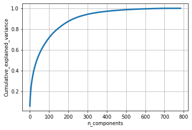

```python
plt.figure(figsize=(6,4))
plt.plot(cumulative_explained_variance,linewidth=3)
plt.grid()

plt.xlabel('n_components')
plt.ylabel('Cumulative_explained_variance')
plt.show()
```

```python
start=datetime.datetime.now()

forest_cv_pca_corrected = GridSearchCV(estimator=forrest, param_grid=forrest_params, cv=5)
forest_cv_pca_corrected.fit(pca_train_data, y)

end=datetime.datetime.now()
print(f'execution time: {end-start}')
```

```
execution time: 0:38:18.154753
```

### Kaggle Submission - Corrected PCA

```python
pca_test_data = pca.fit_transform(standardized_test_data)

forest_pca_corrected_pred = forest_cv_pca_corrected.predict(pca_test_data)
forest_pca_corrected_pred_csv = pd.DataFrame({"ImageId": range(1,len(forest_pca_corrected_pred)+1),"Label": forest_pca_corrected_pred})

forest_pca_corrected_pred_csv.to_csv(root + 'forest_pca_corrected_submission.csv', index=False, header=True)
```

### Kaggle Score: 0.71235

#### Kaggle score has gone down as expected. However, this is the correct approach for production deployments